# Final Project Report - Iris dataset

Xiaohan Li

2024-12-02

# Introduction

## Description of the data set

- This data set contains 150 observations, with 5 variables: sepal length, sepal width, petal length, petal width, and species.
- Each observation represents an iris plant.
- The species has 3 categories: Setosa, Versicolor, and Virginica, with 50 observations for each species.
- One species is linearly separable from the other 2, the latter are not linearly separable from each other.

## Analysis objectives

- Use data visualization to explore the relationships between variables.
- Use data visualization to explore the differences between 3 species.

# Read in data

```r
here::i_am("iris_report.Rmd")

data <- readRDS(
  file = here::here("data/data_clean.rds"))
```

# Tabular Analysis

Characteristics of the 150 plants from the iris data set are displayed in the table below.

```r
table <- readRDS(
  file = here::here("output/table.rds")
)
table
```

[output not shown]

<sup>1</sup> Mean (SD)

- From this table, we can get a general overview of the differences among the 3 species in sepal and petal measurements, including length and width.
- For **setosa** species, the average sepal length, petal length, and petal width are all below the overall average, while its sepal width is above the average.
- Species **setosa** has the smallest average sepal length, petal length, and petal width, but the largest sepal width.
- Species **versicolor** has the smallest average sepal width.
- Species **virginica** has the largest average sepal length, petal length and petal width.

# Graphical Analysis

## Boxplot that showing the sepal length differences between 3 species

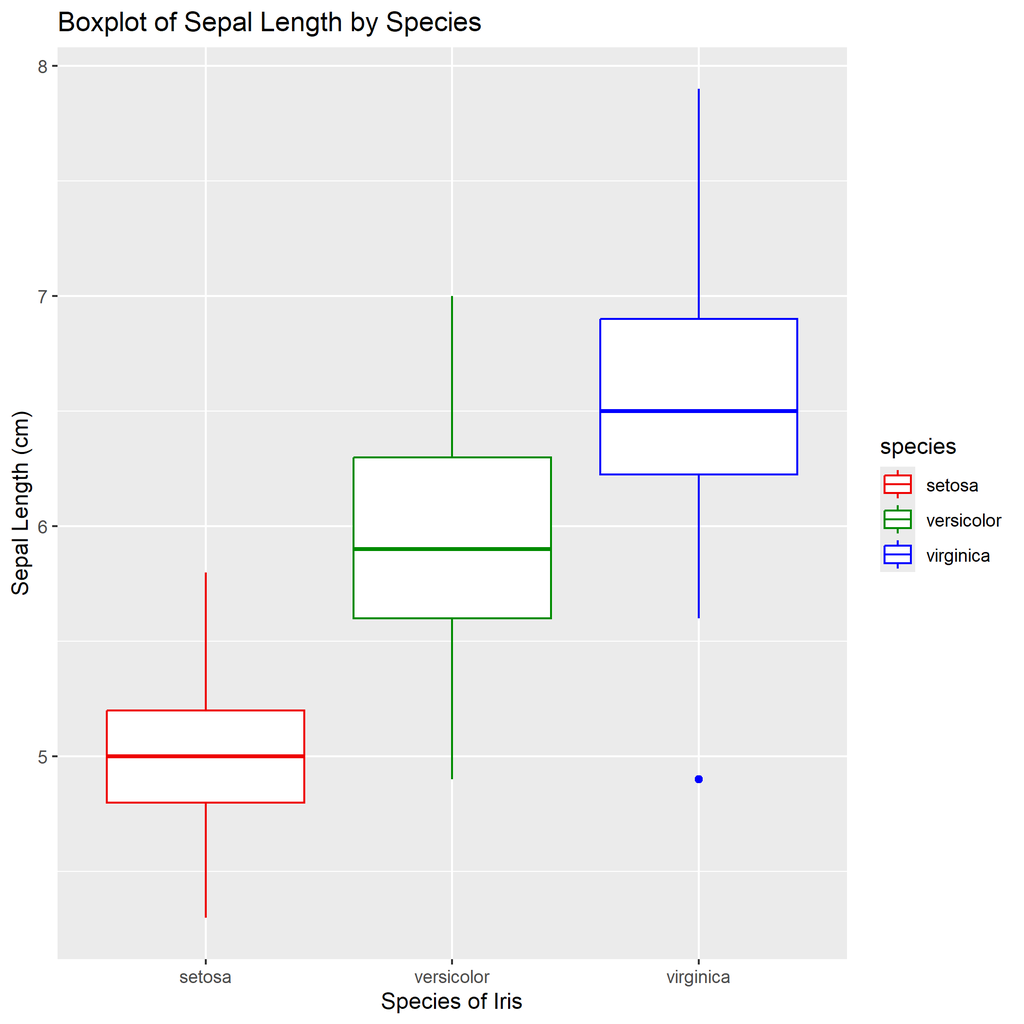

```r
knitr::include_graphics(
  here::here("output/boxplot_sepal_length.png")
)
```

From this boxplot, we can directly see the differences in sepal length among 3 species.

- The average sepal length order is setosa < versicolor < virginica.
- A taller box indicates larger variability. The variability of sepal length in **setosa** is smaller than that of **versicolor** and **virginica**.

## Boxplot that showing the sepal width differences between 3 species

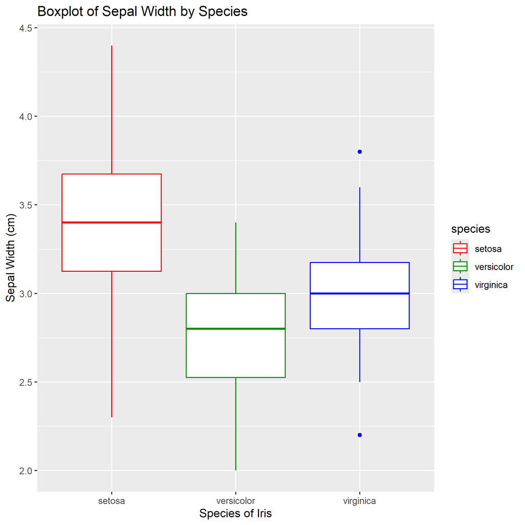

```r
knitr::include_graphics(
  here::here("output/boxplot_sepal_width.png")
)
```

From this boxplot, we can directly see the differences in sepal width among 3 species.